# EDA_CC

### Day3. Data Visualization :

##### 3.1 Univariate Analysis

###### Analyzing individual features:

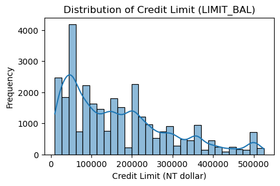

```python
# Histogram for LIMIT_BAL
plt.figure(figsize=(5, 3))
sns.histplot(credit_card_df['LIMIT_BAL'],bins=30,  kde=True)
plt.title('Distribution of Credit Limit (LIMIT_BAL)')
plt.xlabel('Credit Limit (NT dollar)')
plt.ylabel('Frequency')
plt.show()
```

###### Observation :

- The credit limit('LIMIT_BAL') has right skewed distribution.
- there are no outliers,
- there are less probability that people having more than 400000 credit balance.

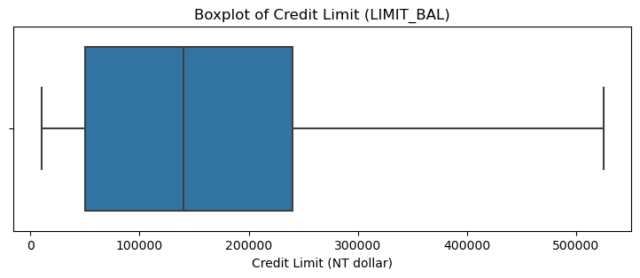

```python
# Boxplot for LIMIT_BAL (to check for outliers)
plt.figure(figsize=(9, 3))
sns.boxplot(x=credit_card_df['LIMIT_BAL'])
plt.title('Boxplot of Credit Limit (LIMIT_BAL)')
plt.xlabel('Credit Limit (NT dollar)')
plt.show()
```

###### Observation :

- the average number of customers lies between 100000 and 200000,
- 75th percentile lies under 2.40000.

###### Analyzing BILL_AMT1-6:

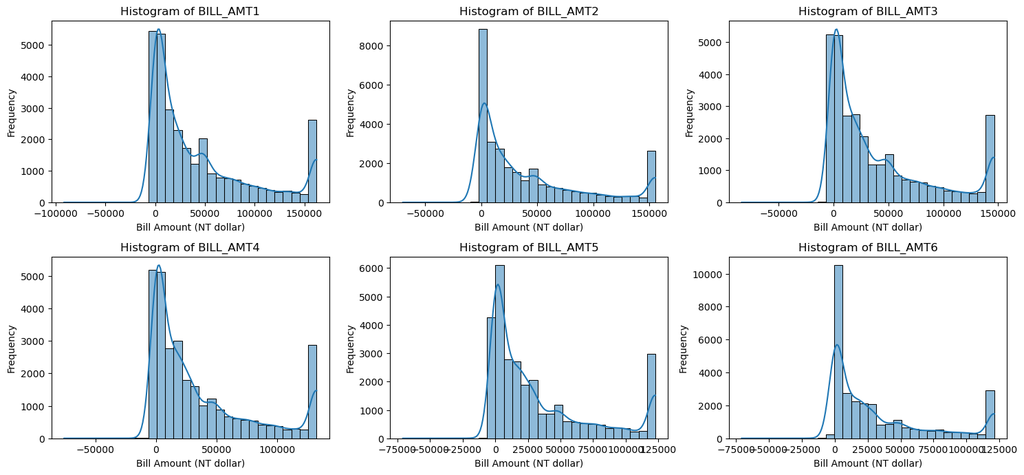

```python
#Histplot to visualize Bill amount for last 6 months.

billamt_features = ['BILL_AMT1', 'BILL_AMT2', 'BILL_AMT3', 'BILL_AMT4', 'BILL_AMT5', 'BILL_AMT6']

plt.figure(figsize=(15, 10))

# Loop through the features and plot histograms
for i, feature in enumerate(billamt_features, 1):
    plt.subplot(3, 3, i)  # Create a 3x3 grid
    sns.histplot(credit_card_df[feature], bins=30, kde=True)  # Use histplot instead of boxplot
    plt.title(f'Histogram of {feature}')
    plt.xlabel('Bill Amount (NT dollar)')
    plt.ylabel('Frequency')

plt.tight_layout()
plt.show()
```

###### Analyzing PAY_AMT1-6:

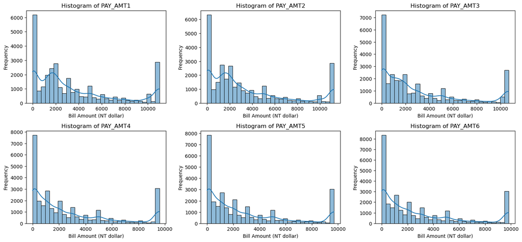

```python
#Histplot to visualize Pay amount for last 6 months.

payamt_features = ['PAY_AMT1', 'PAY_AMT2', 'PAY_AMT3', 'PAY_AMT4', 'PAY_AMT5', 'PAY_AMT6']
plt.figure(figsize=(15, 10))

# Loop through the features and plot histograms
for i, feature in enumerate(payamt_features, 1):
    plt.subplot(3, 3, i)  # Create a 3x3 grid
    sns.histplot(credit_card_df[feature], bins=30, kde=True)  # Use histplot instead of boxplot
    plt.title(f'Histogram of {feature}')
    plt.xlabel('Bill Amount (NT dollar)')
    plt.ylabel('Frequency')

plt.tight_layout()
plt.show()
```

###### Observation :

- In every mounth of pay amount for 6 mounths has right skewed distribution,
- and there is no outliers present.